# Poisson Regression for Daily Total of Bike Counts

## 5 Graphical Comparison

The inferential tables of the Poisson regression models in the previous sections give numerical information about the potential discrepancy across the day of the week. But it is not intuitive. Next, we create a graphic to visualize the relationship between bike totals and day of the week.

First of all, every day has a trend line that reflects the relationship between the bike totals.

$$\text{log-rate} = 7.8463758
+ 0.2783449 \times \text{DayMonday}
- 0.0352409 \times \text{DaySaturday}
+ 1.8792311 \times \text{DaySunday} \\
+ 0.3357880 \times \text{DayThursday}
- 0.5154121 \times \text{DayTuesday}
+ 0.1401522 \times \text{DayWednesday} \\
+ 0.0010256 \times \text{ManhattanBridge}$$

Or equivalently, we can write rate model as

$$rate =\exp(7.8463758
+ 0.2783449 \times \text{DayMonday}
- 0.0352409 \times \text{DaySaturday}
+ 1.8792311 \times \text{DaySunday} \\
+ 0.3357880 \times \text{DayThursday}
- 0.5154121 \times \text{DayTuesday}
+ 0.1401522 \times \text{DayWednesday} \\
+ 0.0010256 \times \text{ManhattanBridge})$$

For example, $\exp(7.8423758)$ gives the bike total rate of the baseline day of the week, Friday. $\exp(7.8423758+0.0010)$ gives the bike total rate of the baseline day, Friday, on the ManhattanBridge. Following the same pattern, you can find the bike total rate for each combination of the day of the week on the ManhattanBridge.

```r
Friday    <- c(exp(7.8463758), exp(7.8463758 + 0.0010256))
Monday    <- c(exp(7.8463758 + 0.2783449), exp(7.8463758 + 0.2783449 + 0.0010256))
Tuesday   <- c(exp(7.8463758 - 0.5154121), exp(7.8463758 - 0.5154121 + 0.0010256))
Wednesday <- c(exp(7.8463758 + 0.1401522), exp(7.8463758 + 0.1401522 + 0.0010256))
Thursday  <- c(exp(7.8463758 + 0.3357880), exp(7.8463758 + 0.3357880 + 0.0010256))
Saturday  <- c(exp(7.8463758 - 0.0352409), exp(7.8463758 - 0.0352409 + 0.0010256))
Sunday    <- c(exp(7.8463758 + 1.8792311), exp(7.8463758 + 1.8792311 + 0.0010256))

minmax = range(c(Friday,Monday, Tuesday, Wednesday, Thursday, Saturday,Sunday))
```

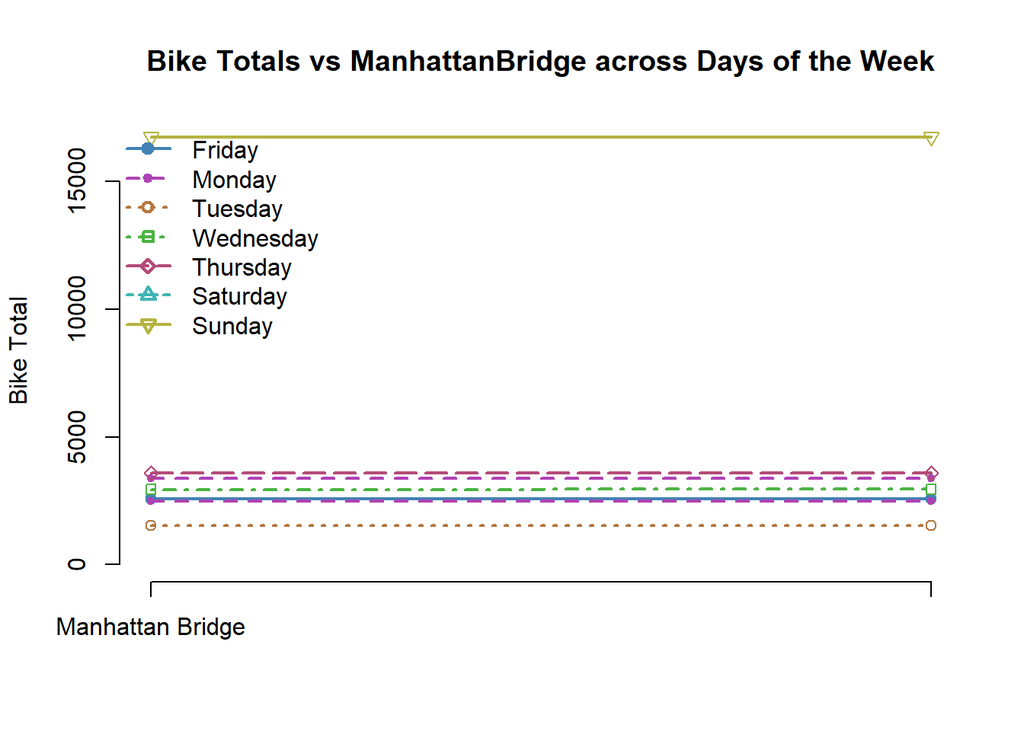

```r
colors = c("#4282B4", "#AF42B4", "#B47842", "#4BB442", "#B44B78", "#42B4B4", "#B4B442")
ltys = 1:7
pchs = 19:25

# Plot Friday first
plot(1:2, Friday, type="l", lty = ltys[1], col=colors[1], lwd = 2,
     xlab="",
     ylab="Bike Total",
     xlim=c(1,2),
     ylim=c(0, max(c(Friday, Monday, Tuesday, Wednesday, Thursday, Saturday, Sunday))),
     main="Bike Totals vs ManhattanBridge across Days of the Week",
     axes=FALSE )
axis(2)
axis(1, labels=c("Manhattan Bridge",""),
     at = 1:2)
points(1:2, Friday, pch=pchs[1], col=colors[1])

# Add other days
lines(1:2, Monday, lty = ltys[2], lwd = 2, col=colors[2])
points(1:2, Monday, pch=pchs[2], col=colors[2])

lines(1:2, Tuesday, lty = ltys[3], lwd = 2, col=colors[3])
points(1:2, Tuesday, pch=pchs[3], col=colors[3])

lines(1:2, Wednesday, lty = ltys[4], lwd = 2, col=colors[4])
points(1:2, Wednesday, pch=pchs[4], col=colors[4])

lines(1:2, Thursday, lty = ltys[5], lwd = 2, col=colors[5])
points(1:2, Thursday, pch=pchs[5], col=colors[5])

lines(1:2, Saturday, lty = ltys[2], lwd = 2, col=colors[2])
points(1:2, Saturday, pch=pchs[2], col=colors[2])

lines(1:2, Sunday, lty = ltys[7], lwd = 2, col=colors[7])
points(1:2, Sunday, pch=pchs[7], col=colors[7])

# Legend
legend("topleft",
       legend=c("Friday","Monday","Tuesday","Wednesday","Thursday","Saturday","Sunday"),
       pch=pchs, lty=ltys, lwd=2, col=colors, bty="n")
```

## 6 Discussions and Conclusions

Several conclusions we can draw from the output of the regression models.

There is no interaction effect between the days of the week and the Manhattan bridge The rate curves are “parallel”.